# COVID 19 Armenia

AS2019547

10/7/2022

# Introduction of Armenia

Armenia is a country in Southwestern Asia.The neighborhood countries of the Armenia are,Georgia,Azerbaijan,Iran,Nakhijevan and Turkey.Territory is about 29.74 thousand square kilometers. As of 2022 January 1,population of the country is 2961 thousand.

### Climate

Armenia has significant annual variance in temperature.There are four seasons Winter that lasting from June to mid September,Summer, short Spring and long Autumn.in summer temperature is fluctuates between 22 and 36 Celsius.

### Economy

The economy of the Armenia relies heavily on investment and support from Armenians abroad.

### Health

In Armenia medical treatment in hospitals and clinics is free of charge for all citizens.

# Exploratory Data Analysis

```r
# coronavirus data set & displaying first 6 rows of the data set.
library(coronavirus)
data(coronavirus)
head(coronavirus)
```

**There are 742560 observations of variables in the coronavirus data set.It contains the daily summary of Coronavirus cases,by state.**

```
##         date province country     lat    long      type cases uid iso2 iso3
## 1 2020-01-22     <NA> Armenia 40.0691 45.0382 confirmed     0  51   AM  ARM
## 2 2020-01-23     <NA> Armenia 40.0691 45.0382 confirmed     0  51   AM  ARM
## 3 2020-01-24     <NA> Armenia 40.0691 45.0382 confirmed     0  51   AM  ARM
## 4 2020-01-25     <NA> Armenia 40.0691 45.0382 confirmed     0  51   AM  ARM
## 5 2020-01-26     <NA> Armenia 40.0691 45.0382 confirmed     0  51   AM  ARM
## 6 2020-01-27     <NA> Armenia 40.0691 45.0382 confirmed     0  51   AM  ARM
##   code3 combined_key population continent_name continent_code
## 1    51      Armenia    2963234           Asia             AS
## 2    51      Armenia    2963234           Asia             AS
## 3    51      Armenia    2963234           Asia             AS
## 4    51      Armenia    2963234           Asia             AS
## 5    51      Armenia    2963234           Asia             AS
## 6    51      Armenia    2963234           Asia             AS
```

**We can filter 2652 observations of Armenia COVID 19 cases from the coronavirus data set.The daily coronavirus cases collected from 2020-01-22 to 2022-06-23.**

```r
#check the columns for missing data
mean(armenia_corona)
```

```
## [1] NA
```

There are missing values in the data set.

```r
# code missing values to NA
armenia_corona <- armenia_corona %>% mutate(cases = replace(cases, which(cases < 0), NA))
summary(armenia_corona)
```

```
      date              province           country               lat
 Min.   :2020-01-22   Length:2652        Length:2652        Min.   :40.07
 1st Qu.:2020-08-29   Class :character   Class :character   1st Qu.:40.07
 Median :2021-04-07   Mode  :character   Mode  :character   Median :40.07
 Mean   :2021-04-07                                         Mean   :40.07
 3rd Qu.:2021-11-14                                         3rd Qu.:40.07
 Max.   :2022-06-23                                         Max.   :40.07

      long           type               cases             uid
 Min.   :45.04   Length:2652        Min.   :   0.0   Min.   :51
 1st Qu.:45.04   Class :character   1st Qu.:   1.0   1st Qu.:51
 Median :45.04   Mode  :character   Median :  22.0   Median :51
 Mean   :45.04                      Mean   : 246.1   Mean   :51
 3rd Qu.:45.04                      3rd Qu.: 262.8   3rd Qu.:51
 Max.   :45.04                      Max.   :8319.0   Max.   :51
                                    NA's   :2
     iso2               iso3               code3    combined_key
 Length:2652        Length:2652        Min.   :51   Length:2652
 Class :character   Class :character   1st Qu.:51   Class :character
 Mode  :character   Mode  :character   Median :51   Mode  :character
                                       Mean   :51
                                       3rd Qu.:51
                                       Max.   :51

   population      continent_name     continent_code
 Min.   :2963234   Length:2652        Length:2652
 1st Qu.:2963234   Class :character   Class :character
 Median :2963234   Mode  :character   Mode  :character
 Mean   :2963234
 3rd Qu.:2963234
 Max.   :2963234
```

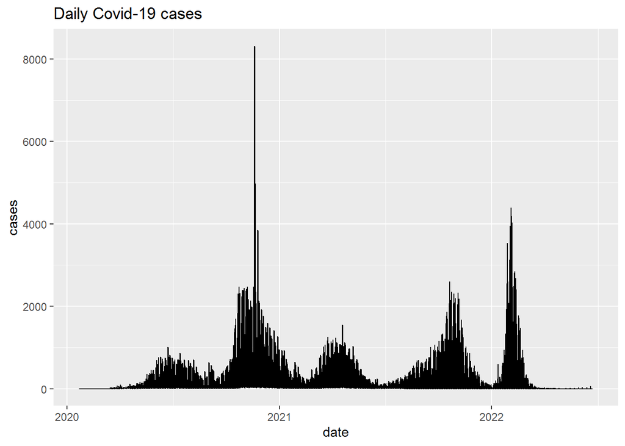

**According to the above summary output and the figure of the cases,maximum number of corona cases recorded within a day is 8319.And the minimum is 0.Average number of corona cases over the whole two years is 246.**

```
##    Min. 1st Qu.  Median    Mean 3rd Qu.    Max.
##     0.0    62.0   239.0   478.6   621.0  4388.0
```

```r
sum(confirmed_cases$cases)
```

```
## [1] 423104
```

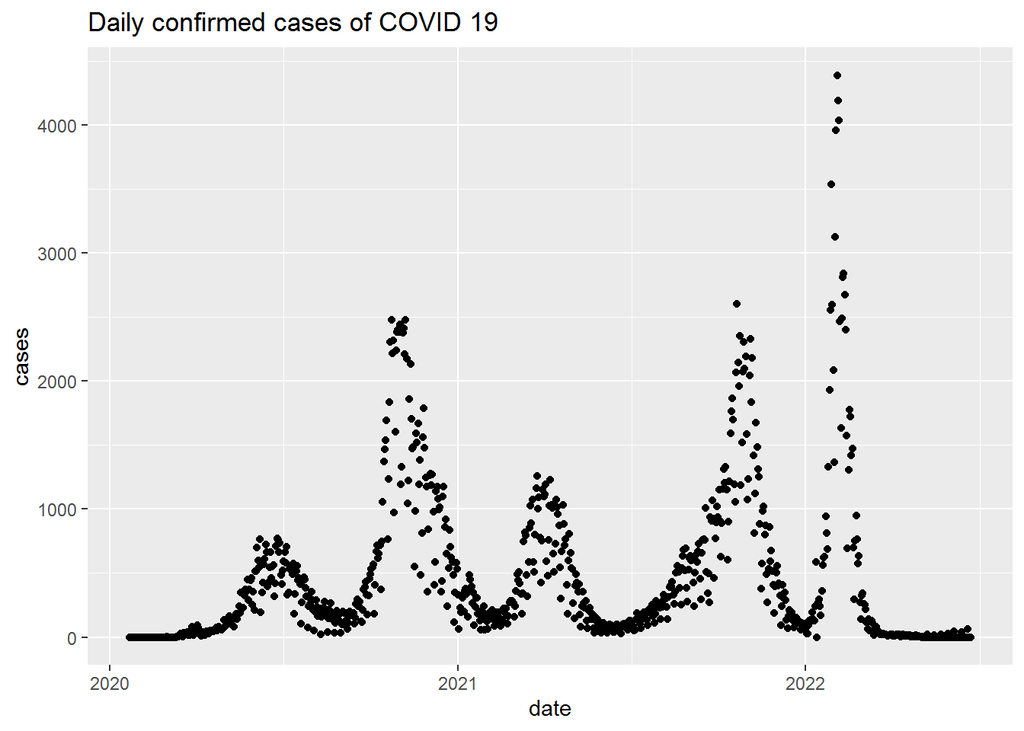

**This graph shows daily confirmed cases.According to the summary also maximum daily confirmed cases is 4388.All number of cases confimed over the time is 423104.We can see some cyclical & sesonal behaviour over the time.**

```
##    Min. 1st Qu.  Median    Mean 3rd Qu.    Max.    NA's
##     0.0     0.0    48.0   249.6   300.0  8319.0       1
```

```
## [1] 220438
```

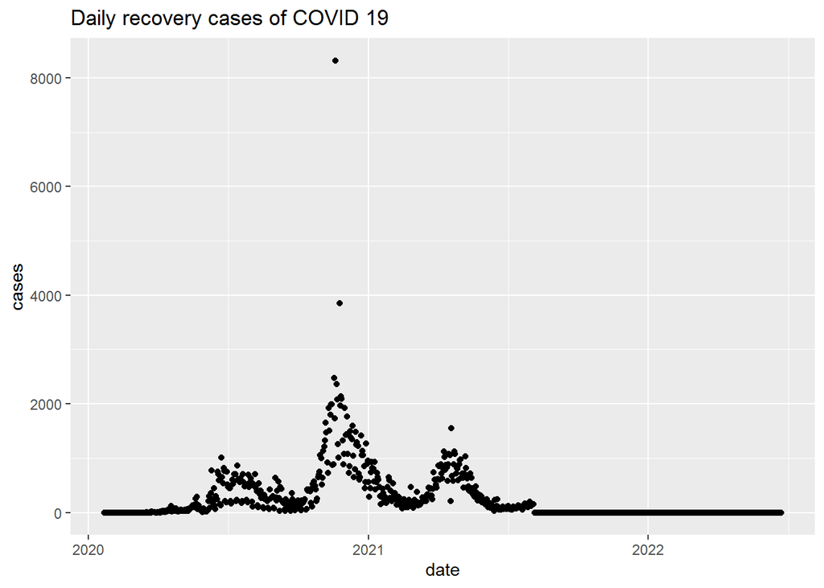

**There are no recovery cases at the beginning of 2020 and end of the 2022.In the end of 2020 & the beginning of 2021 there are some recovery cases than other time periods.**

```
##    Min. 1st Qu.  Median    Mean 3rd Qu.    Max.    NA's
##   0.000   1.000   5.000   9.775  15.000  70.000       1
```

```
## [1] 8631
```

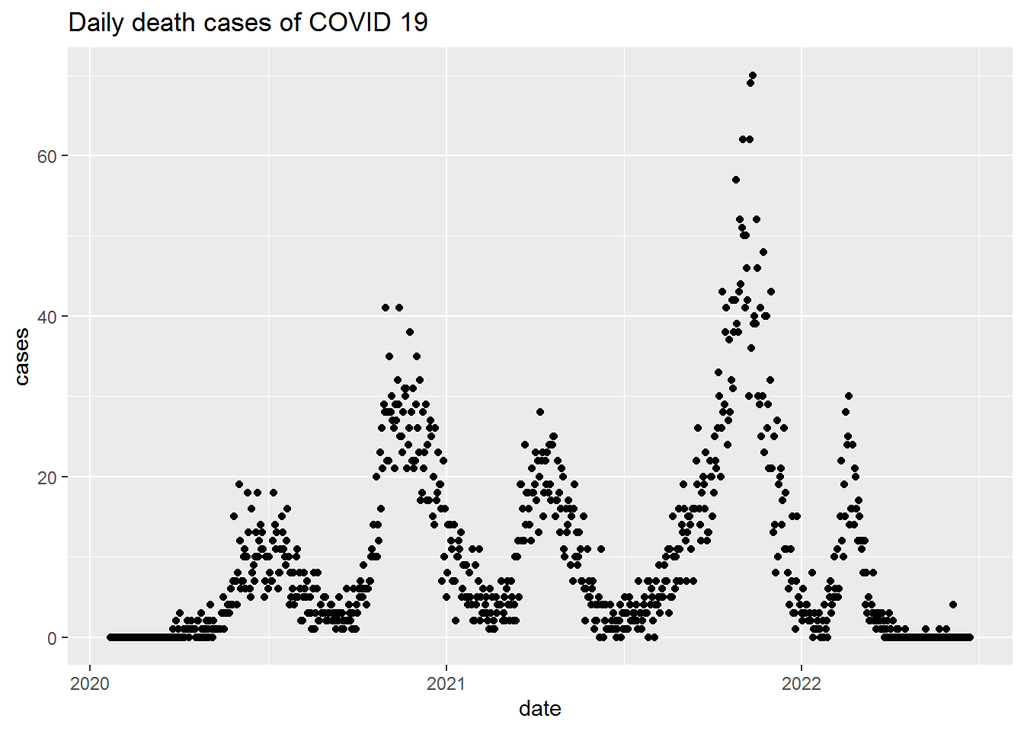

**It can be see some seasonal pattern in the death cases in both two years.The highest death cases happened in the last of 2021**

[figure not shown]

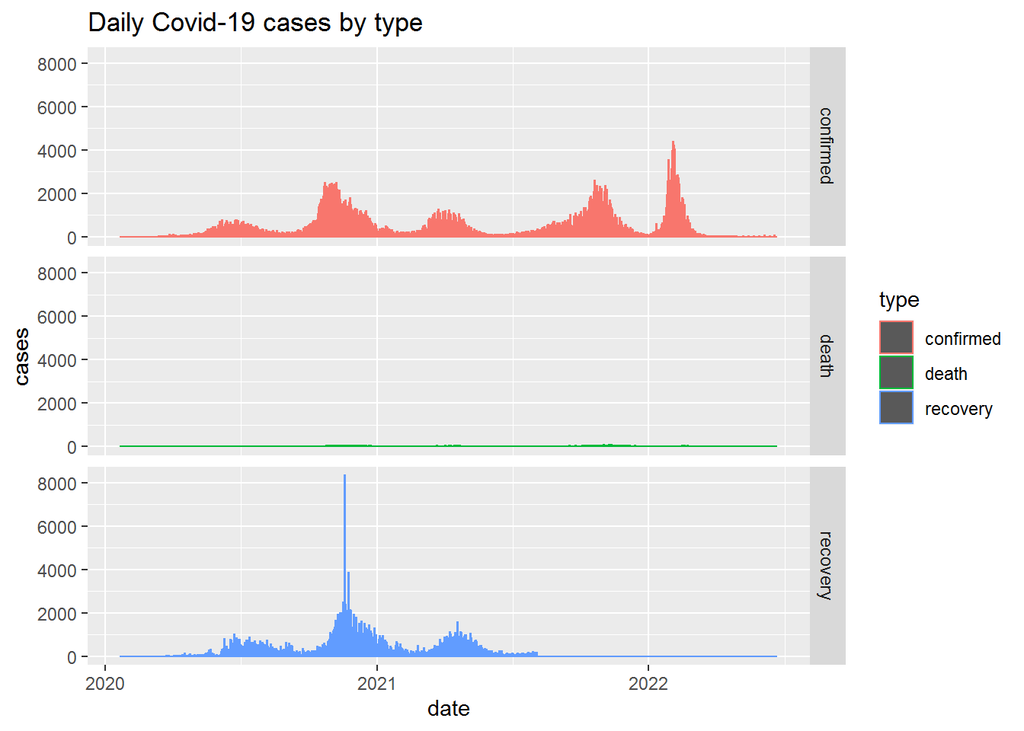

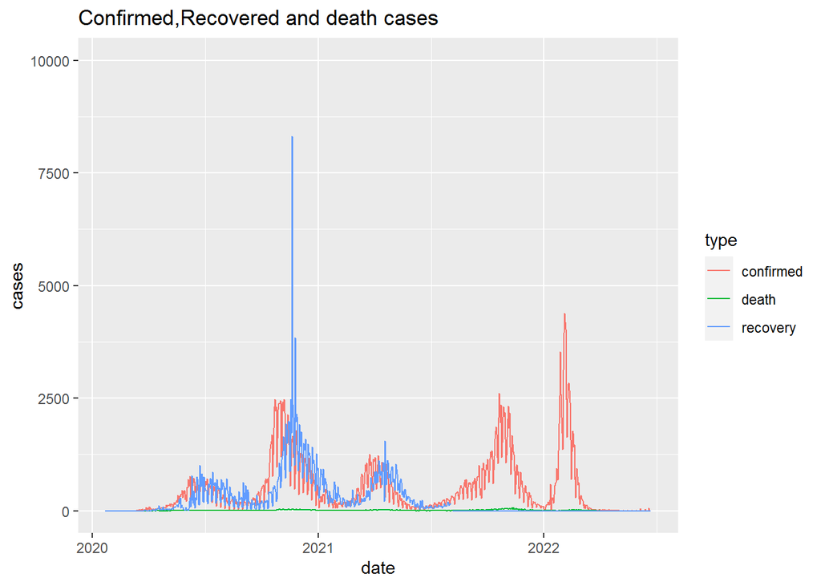

**According to the above two figures.Since the year 2020 to first half of 2021,there is no significant difference between confirmed and recovery cases.At the end of 2020 there is higher recovery cases with compared to the confirmed cases.After the first half of the year 2021,there can not be seen any recovery cases.Death cases can be seen as insignificant with respect to other two cases.**

```
##                   confirmed      death  recovered
## total            423104.000   8631.000 220438.000
## mean                478.600      9.775    249.600
## max                4388.000     70.000   8319.000
## total percentage     64.876      1.323     33.800
```

**AS a summery ,death corona case percentage is very small.Confirmed percentage is as twice as recovered.**

# Comparison with other countries.

*Iran*

```
##    Min. 1st Qu.  Median    Mean 3rd Qu.    Max.    NA's
##     0.0    70.5   523.0  4082.2  6125.5 50228.0       1
```

*Turkey*

```
##    Min. 1st Qu.  Median    Mean 3rd Qu.    Max.    NA's
##       0      20     276    7794    5861 1123456       1
```

*Georgia*

```
##    Min. 1st Qu.  Median    Mean 3rd Qu.    Max.    NA's
##     0.0     0.0    18.0   779.7   552.5 26320.0       1
```

*Azerbaijan*

```
##    Min. 1st Qu.  Median    Mean 3rd Qu.    Max.    NA's
##       0       0      27     429     318    7779       3
```

*nakhijevan*

[output not shown]

*Syria*

```
##    Min. 1st Qu.  Median    Mean 3rd Qu.    Max.    NA's
##    0.00    0.00    4.00   30.59   41.00  905.00       1
```

*Sri Lanka*

```
##    Min. 1st Qu.  Median    Mean 3rd Qu.    Max.    NA's
##     0.0     0.0    13.0   364.3   370.0 11366.0       3
```

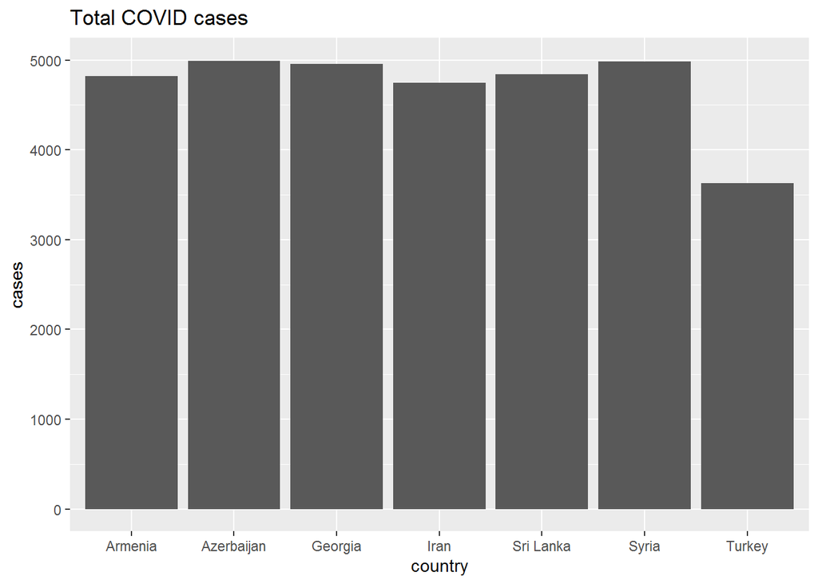

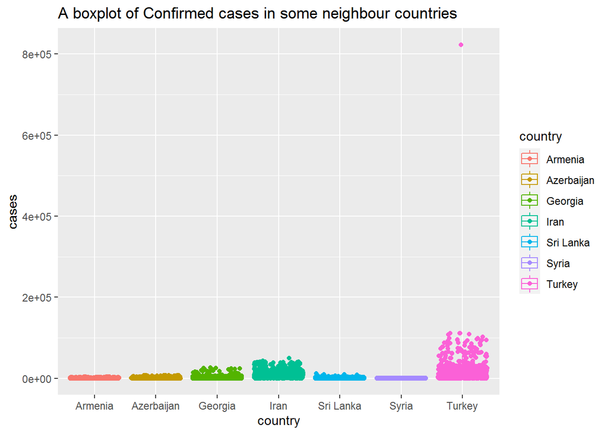

**IN the 2020 -2022 year time period ,most confirm cases are recorded among above contries from Turkey.secondly in Iran.**

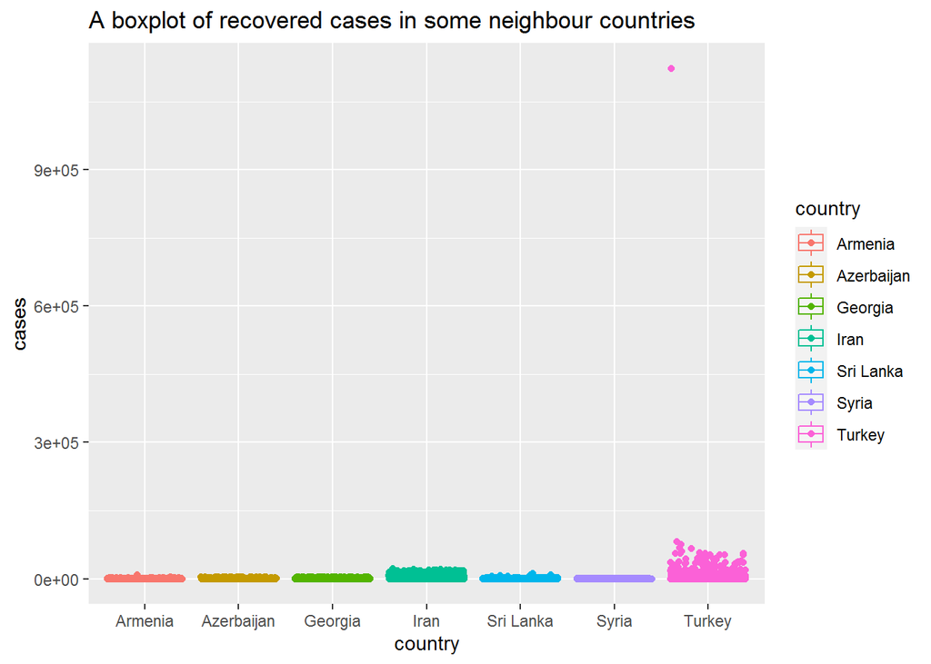

**Recovery cases also high in Turkey.Other countries have approximatly similar number of recovery cases.**

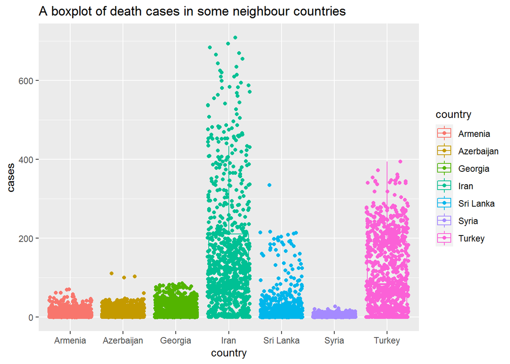

**This box plot clearly shows Iran has the maximum death cases.It has very large significant difference among others.Second largest number of cases are in Turkey and thirdly Sri Lanka.Armenia and Azerbaijan has no significant difference.**

# Discussion

**According to the analysis of Armenia COVID 19 cases data set,we can’t say that Armenia is extremely god or bad.They managed the deaths with respect to the confirmed cases.But after the first six months 2021 ,recovery cases are reduced.There fore Armenia should pay attention for recovering the COVID cases.Their number of confirmed cases are as twice as recoveries.Therefore make their attention to reduce corona cases by make COVID rules and health care followings,will be a decision.** **Analyzing their neighborhood countries Iran & Turkey provide surprising result of death cases.While others are surrounded countries,I choose Sri Lanka also compared as it is also a Asian country and as Sri Lankans our responsibility is save from COVID 19 by following health care rules.**

# Conclusions

## REFERENCES

[1] https://www.britannica.com/place/Armenia/Settlement-patterns#ref44253

[2] https://www.gov.am/en/

[3] https://en.wikipedia.org/wiki/Armenia